# White Wine: Analyzing the Variables by Ryan Heerwagen

# Univariate Plots Section

### Overview of the variables:

To start off with, a good overview of the data would be helpful

```r
summary(whitwine)
```

```
##        X        fixed.acidity    volatile.acidity  citric.acid
##  Min.   :   1   Min.   : 3.800   Min.   :0.0800   Min.   :0.0000
##  1st Qu.:1225   1st Qu.: 6.300   1st Qu.:0.2100   1st Qu.:0.2700
##  Median :2450   Median : 6.800   Median :0.2600   Median :0.3200
##  Mean   :2450   Mean   : 6.855   Mean   :0.2782   Mean   :0.3342
##  3rd Qu.:3674   3rd Qu.: 7.300   3rd Qu.:0.3200   3rd Qu.:0.3900
##  Max.   :4898   Max.   :14.200   Max.   :1.1000   Max.   :1.6600
##  residual.sugar     chlorides       free.sulfur.dioxide
##  Min.   : 0.600   Min.   :0.00900   Min.   :  2.00
##  1st Qu.: 1.700   1st Qu.:0.03600   1st Qu.: 23.00
##  Median : 5.200   Median :0.04300   Median : 34.00
##  Mean   : 6.391   Mean   :0.04577   Mean   : 35.31
##  3rd Qu.: 9.900   3rd Qu.:0.05000   3rd Qu.: 46.00
##  Max.   :65.800   Max.   :0.34600   Max.   :289.00
##  total.sulfur.dioxide    density             pH          sulphates
##  Min.   :  9.0        Min.   :0.9871   Min.   :2.720   Min.   :0.2200
##  1st Qu.:108.0        1st Qu.:0.9917   1st Qu.:3.090   1st Qu.:0.4100
##  Median :134.0        Median :0.9937   Median :3.180   Median :0.4700
##  Mean   :138.4        Mean   :0.9940   Mean   :3.188   Mean   :0.4898
##  3rd Qu.:167.0        3rd Qu.:0.9961   3rd Qu.:3.280   3rd Qu.:0.5500
##  Max.   :440.0        Max.   :1.0390   Max.   :3.820   Max.   :1.0800
##     alcohol         quality
##  Min.   : 8.00   Min.   :3.000
##  1st Qu.: 9.50   1st Qu.:5.000
##  Median :10.40   Median :6.000
##  Mean   :10.51   Mean   :5.878
##  3rd Qu.:11.40   3rd Qu.:6.000
##  Max.   :14.20   Max.   :9.000
```

From this we can tell that there are clearly some values that are skewed and have outliers, like residual sugar.

### Looking at quality distribution

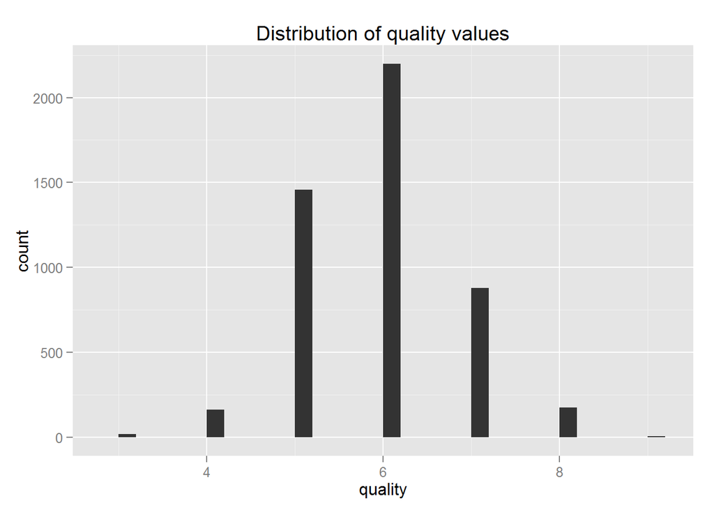

This distribution does not quite look normal. Let’s try another model.

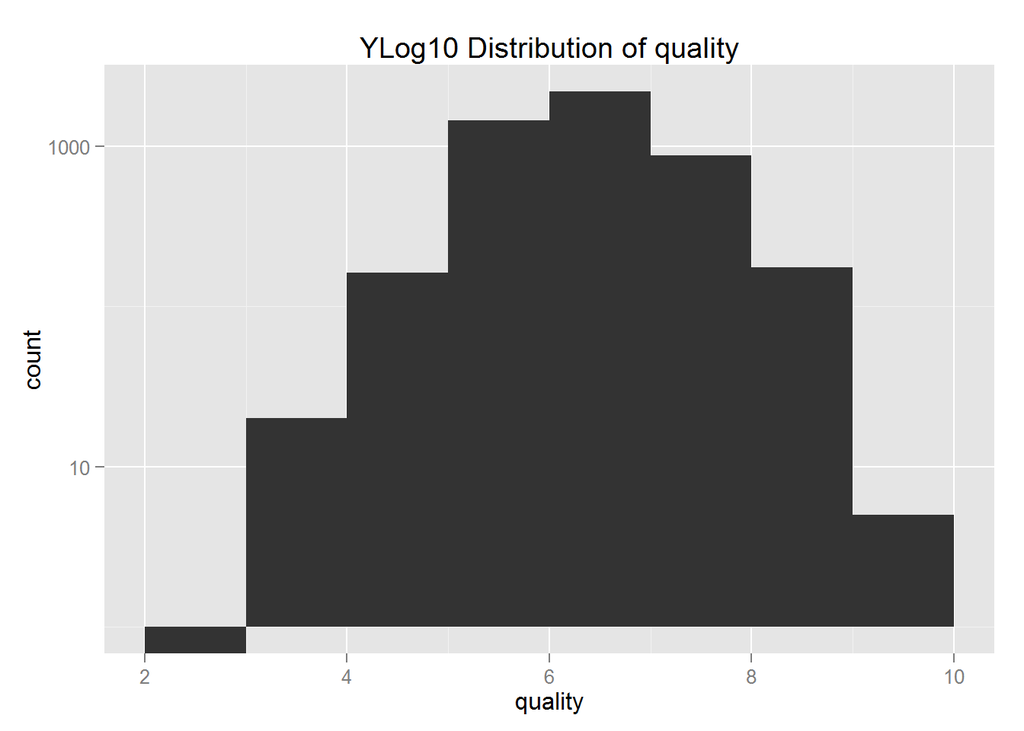

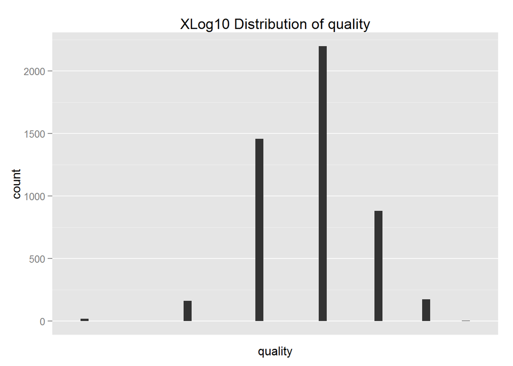

Neither effort really seems to help dispel the concern. It’s quite plausible that a large part of the issue is just that the values are discrete and limited in range, as opposed to a more continuous variable.

### Investigating distribution of other variables

To focus a bit more on other variables, to better understand their distributions and qualities.

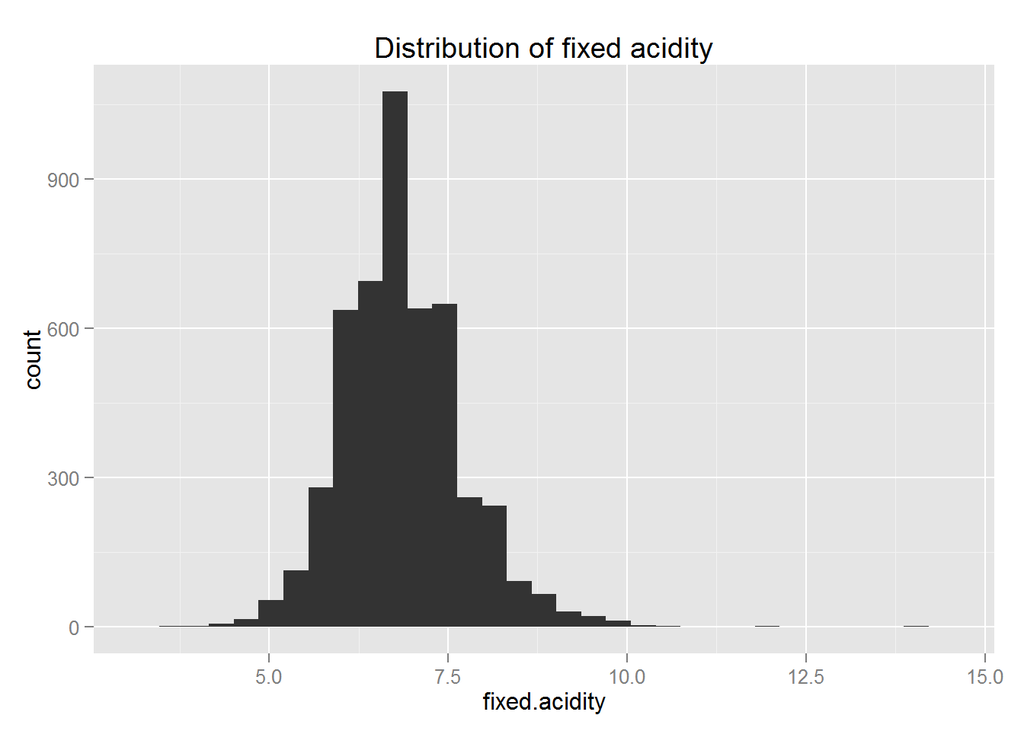

The distribution of fixed acidity does look more normal.

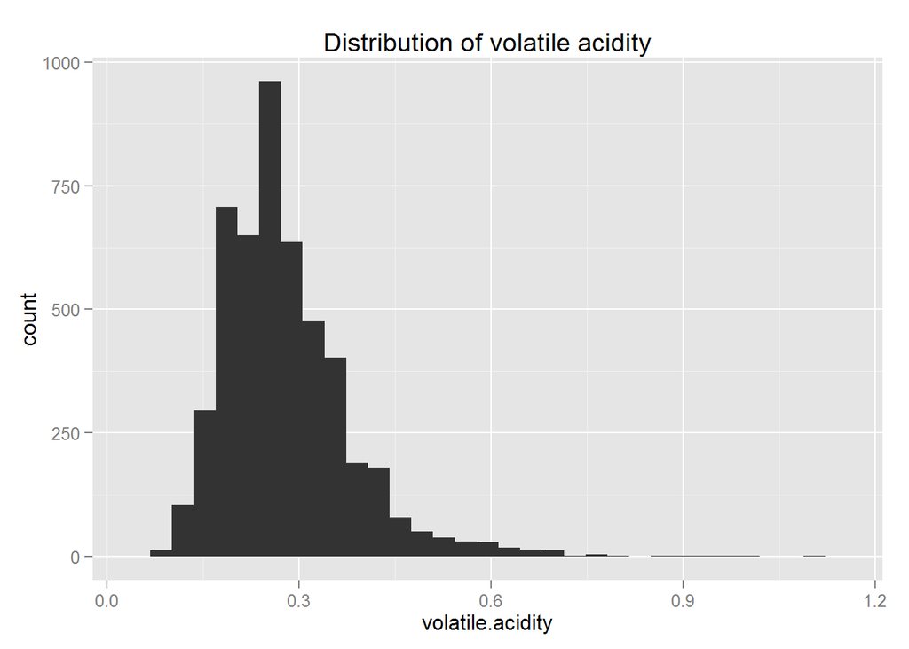

The distribution of volatile acidity appears to have a positive skew.

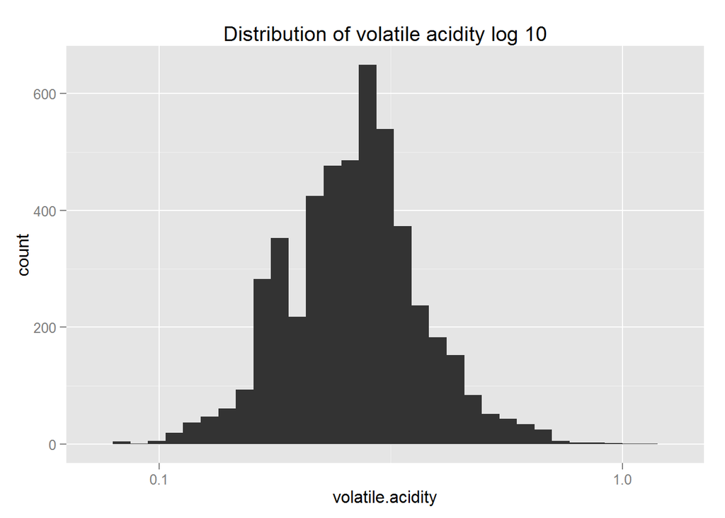

Adjusting the scale by log 10 does make the chart look more normal, but the center looks more erratic as the edges start to look more normal.

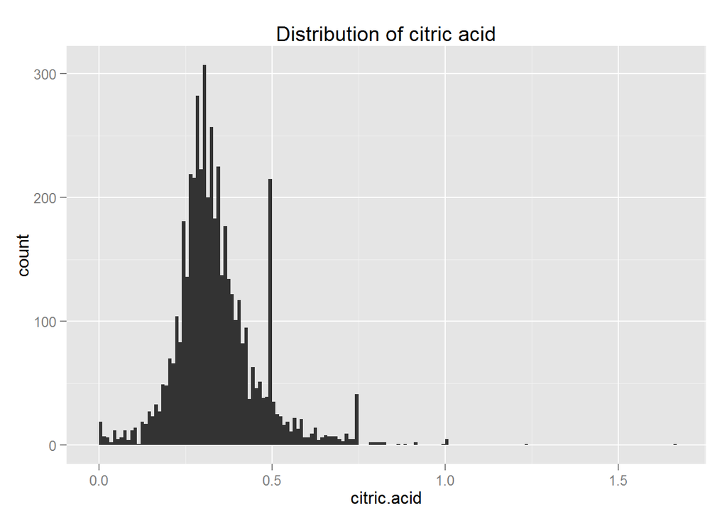

Citric acid appears to have a minor positive skew, but also just some outliers on the right side. There is a strange spike around .5 g / dm^3 for citric acid.

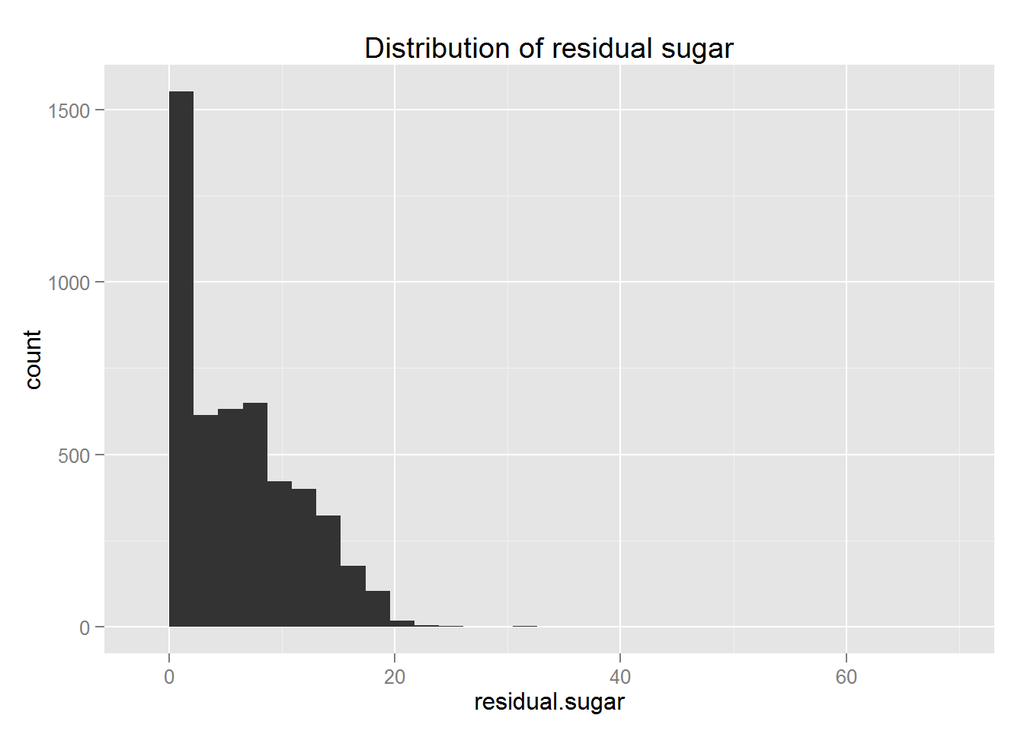

Residual sugar just does not have a normal distribution, and much of the distribution is stuck on the 0 bound. There are significant outliers on the upper bound.

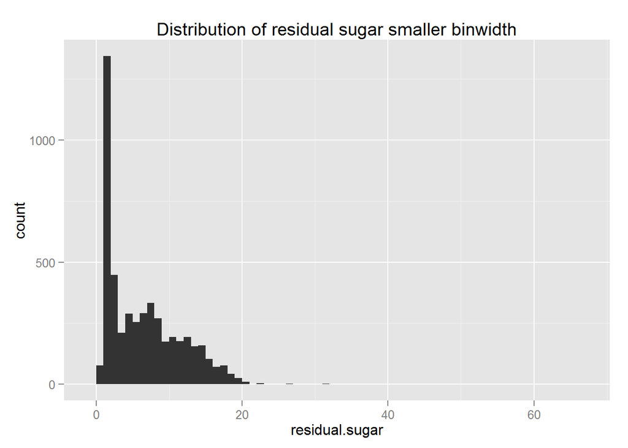

As can be seen from having smaller binwidths, the actual value with the highest count is slightly above zero.

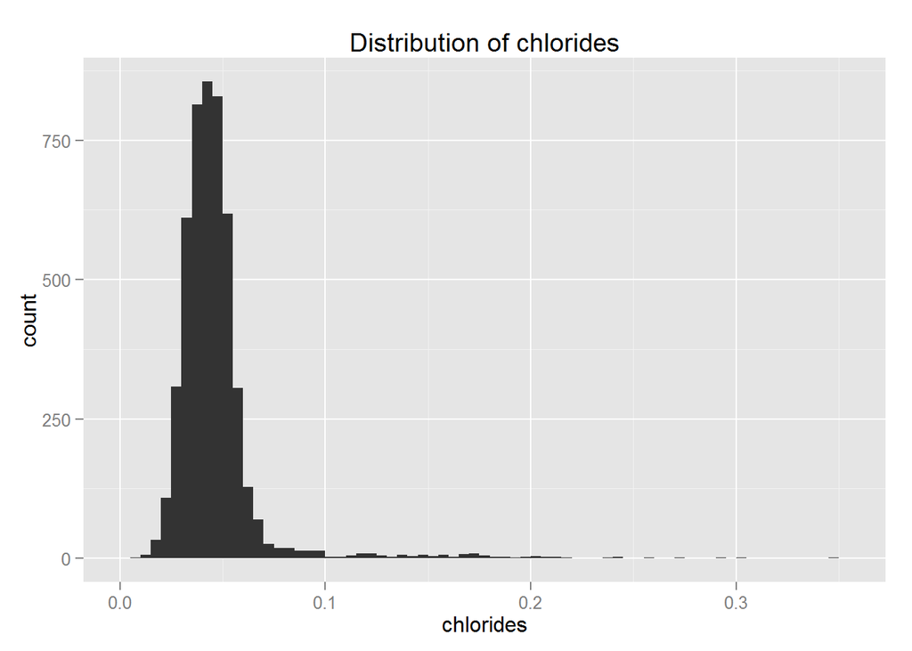

Using a small binwidth, it seems like the chlorides have a normal distribution with a long tail on the right side of the chart. There are a lot of outliers.

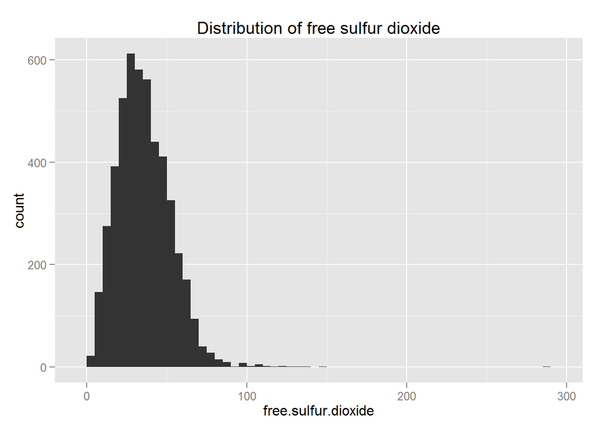

The distribution has a clear positive skew, although a very minor one. There are clearly some outliers given how the plot is centered, and it looks more like a normal graph with a few positive values.

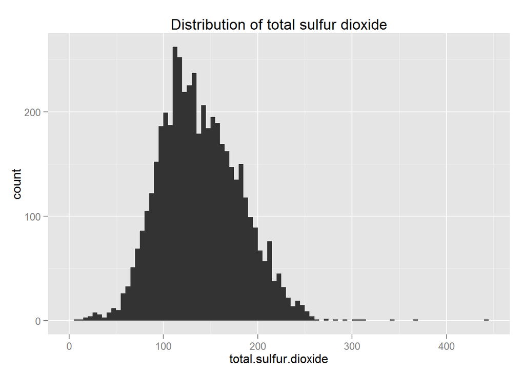

The distribution looks like it has normal tendencies, but the distribution near the peak is somewhat erratic. I am not seeing an additional pattern.

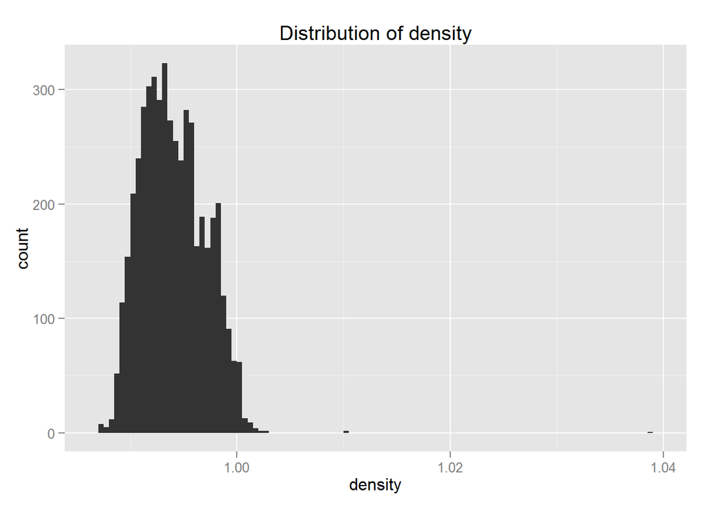

This distribution appears non-normal, mostly clustered around the center with some clear outliers.

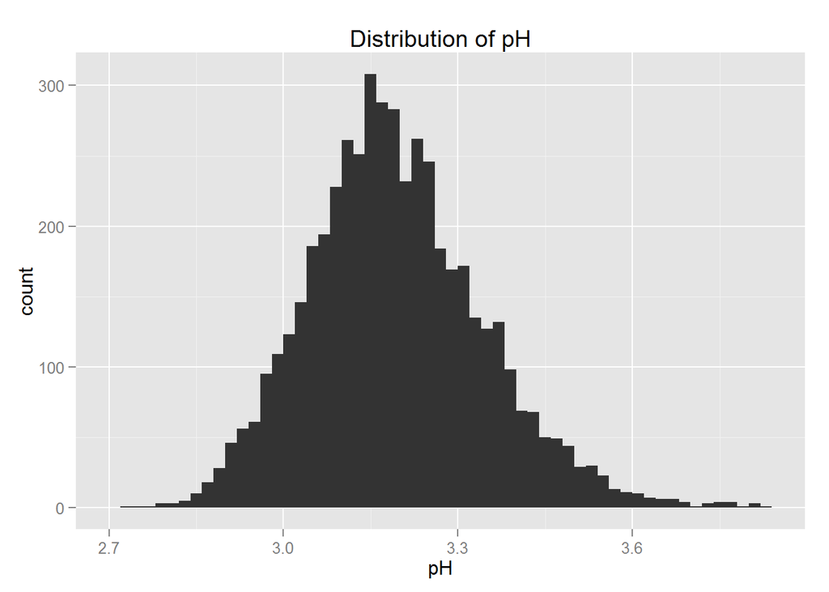

The distribution of pH looks broadly normal. It has some positive skew as the graph isn’t centered around the median, and it’s relatively choppy at places.

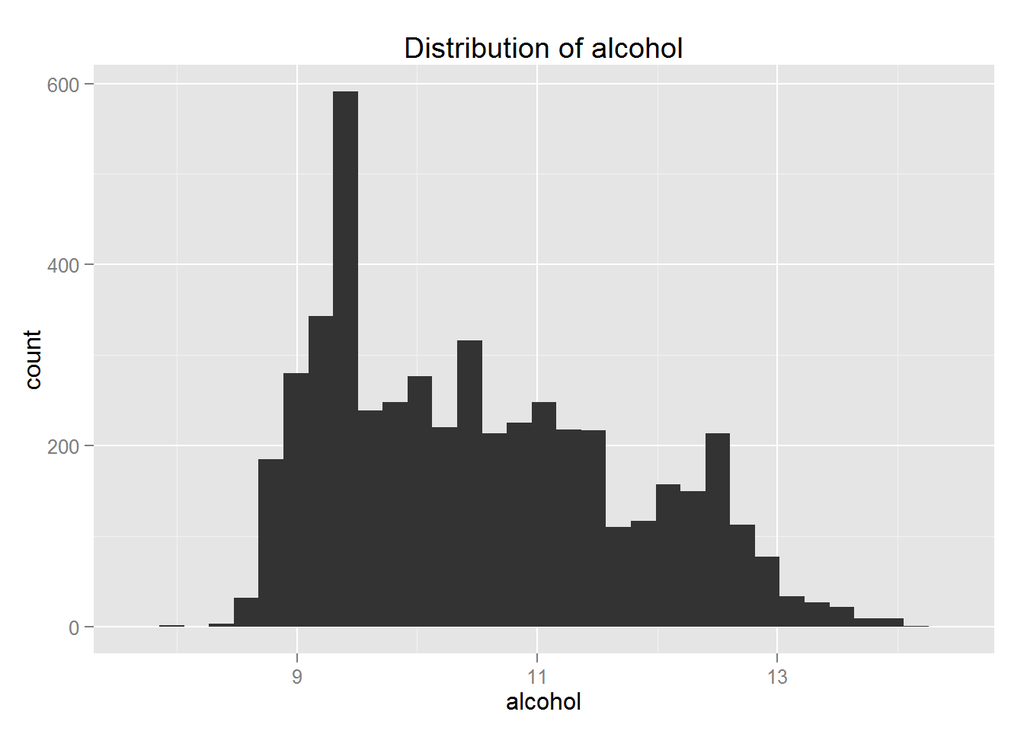

This distribution is clearly non-normal. There is a high point around 9.5% alcohol, and it slowly fades down as the percent increases.

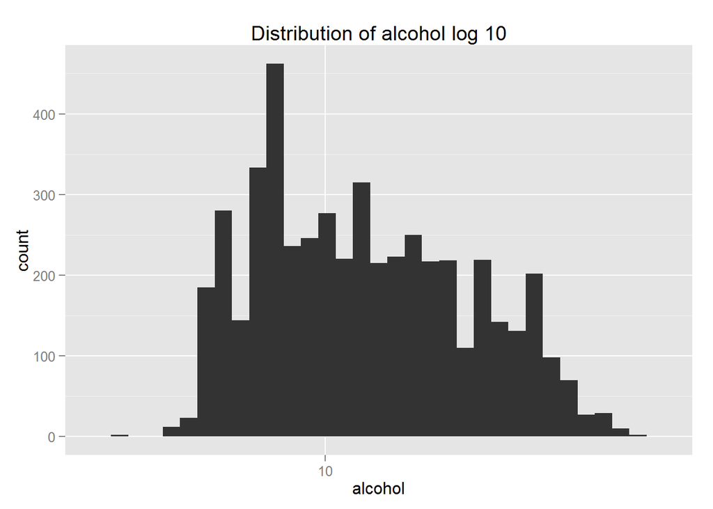

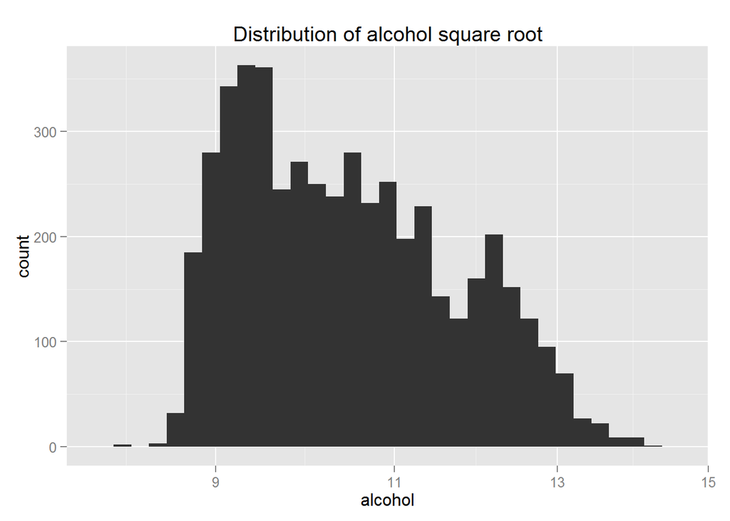

Other efforts do not seem to clear this up either, and having a distribution that follows a simple pattern may not occur for all data.

# Univariate Analysis

### What is the structure of your dataset?

There are 4898 observations of 12 variables(fixed.acidity, volatile.acidity, citric.acid, residual.sugar, chlorides, free.sulfur.dioxide, total.sulfur.dioxide, density, pH, sulphates, alcohol, and quality) for a set of white wines.

The median and mean quality are similar and set close to 6. The data is not normalized relative to quality. The minimum alcohol content is 8%, the mean and median around around 10.4-10.5%, and the max is 14.2% Given a bit of background research: http://www.realsimple.com/holidays-entertaining/entertaining/food-drink/alcohol-content-wine this suggests that the sample of wine we have may have unusually low alcohol content.

### What is/are the main feature(s) of interest in your dataset?

The main feature of interest is quality.

### What other features in the dataset do you think will help support your investigation into your feature(s) of interest?

I think alcohol, density, and bound sulfur dioxide are very important variables.

### Did you create any new variables from existing variables in the dataset?

I created a variable tracking the variance from the mean for residual sugar, as well as a measure of bound sulfur dioxide by subtracting free from the total. I also created a few ordered factors for alcohol and quality test relationships within groupings. Finally, I created an M table for the purposes of checking correlations.

### Of the features you investigated, were there any unusual distributions? Did you perform any operations on the data to tidy, adjust, or change the form of the data? If so, why did you do this?

The distribution of residual sugar hit the bottom wall of zero. Also, sulphates, residual sugar, chlorides, free and bound sulfure dioxide, fixed and volatile acidity, and citric acide all have major outliars.

I made adjustments to these to tidy up the graphs by limiting the x axis.

# Bivariate Plots Section

Comparison graphs between quality and other variables. The idea is to better understand what the relationship is between quality and this other variable. A correlation and a scatterplot are used to better perceive the relationship, as a scatterplot can detect strange things like non-linear shapes, or interesting sorts of heteroscedasticity that line plots and other charts will not.

### Investigating quality vs other variables

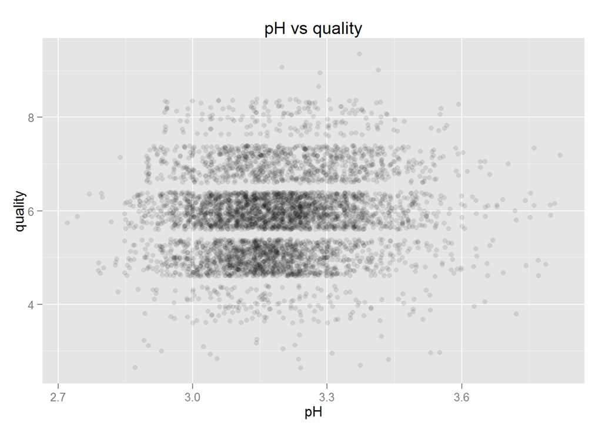

```
##
##  Pearson's product-moment correlation
##
## data:  whitwine$quality and whitwine$pH
## t = 6.9917, df = 4896, p-value = 3.081e-12
## alternative hypothesis: true correlation is not equal to 0
## 95 percent confidence interval:
##  0.07162022 0.12707983
## sample estimates:
##        cor
## 0.09942725
```

What can be determined from both the graph and the correlation test is that there isn’t a strong relationship between pH and quality. The correlation test does let us know that there is a small correlation between the two variables.

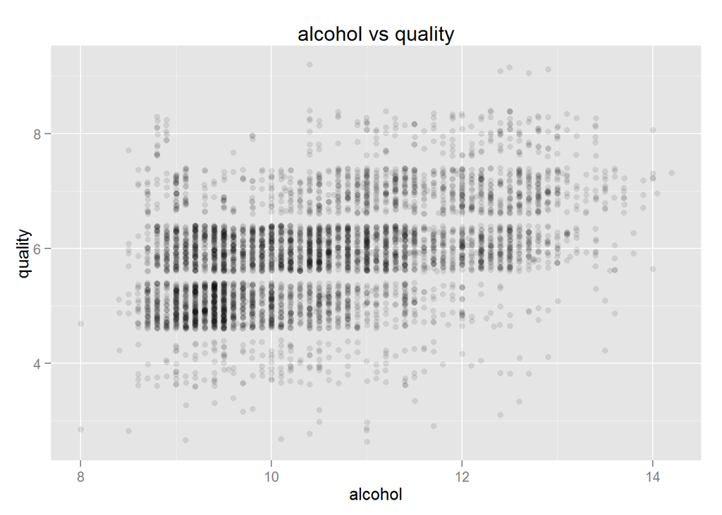

```
##
##  Pearson's product-moment correlation
##
## data:  whitwine$quality and whitwine$alcohol
## t = 33.858, df = 4896, p-value < 2.2e-16
## alternative hypothesis: true correlation is not equal to 0
## 95 percent confidence interval:
##  0.4126015 0.4579941
## sample estimates:
##       cor
## 0.4355747
```

While it might not be perfectly clear from the graph, it is clear from the correlation test that there is a correlation between the two variables. It is a low correlation, so it isn’t the easiest to visually detect.

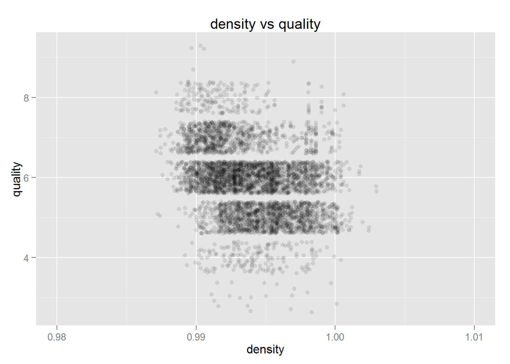

```
##
##  Pearson's product-moment correlation
##
## data:  whitwine$quality and whitwine$density
## t = -22.581, df = 4896, p-value < 2.2e-16
## alternative hypothesis: true correlation is not equal to 0
## 95 percent confidence interval:
##  -0.3322718 -0.2815385
## sample estimates:
##        cor
## -0.3071233
```

Also, while it might not be perfectly clear from the graph, there is a correlation between the two variables. The correlation is relatively low at around -.3.

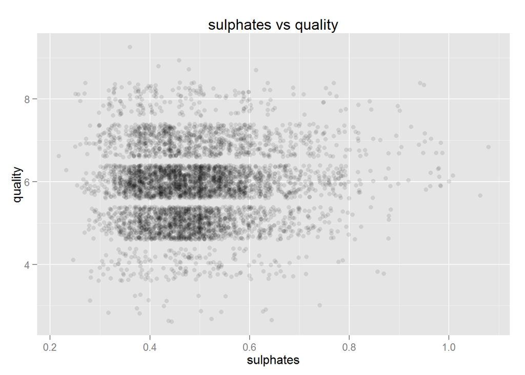

```
##
##  Pearson's product-moment correlation
##
## data:  whitwine$quality and whitwine$sulphates
## t = 3.7613, df = 4896, p-value = 0.000171
## alternative hypothesis: true correlation is not equal to 0
## 95 percent confidence interval:
##  0.02571007 0.08156172
## sample estimates:
##        cor
## 0.05367788
```

The correlation between sulphates and quality is incredibly low. The graph looks like it is 0, and even running a test while clearly indicating a correlation that is not 0, is not showing one with much predictive power.

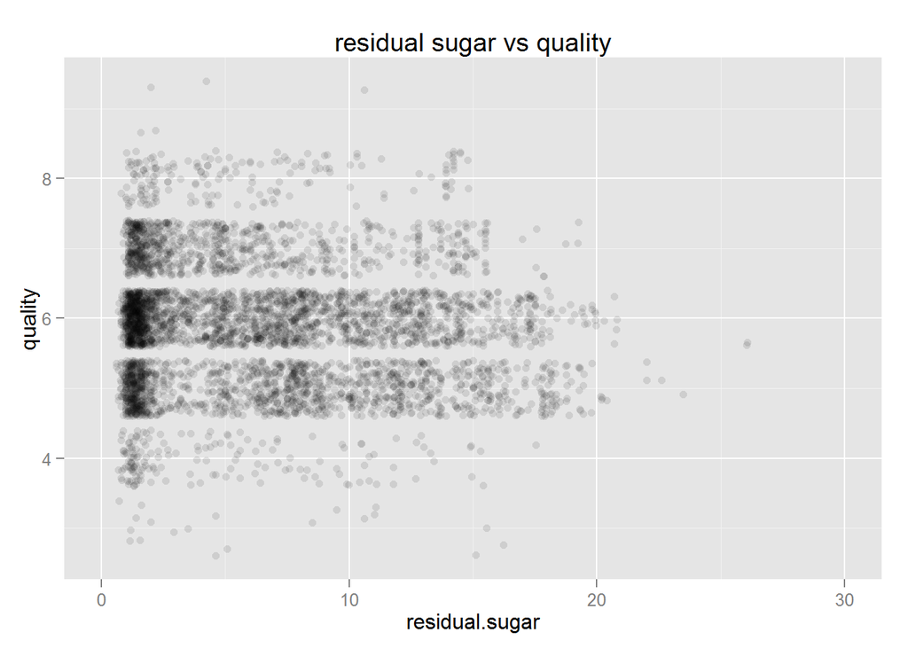

```
##
##  Pearson's product-moment correlation
##
## data:  whitwine$quality and whitwine$residual.sugar
## t = -6.8603, df = 4896, p-value = 7.724e-12
## alternative hypothesis: true correlation is not equal to 0
## 95 percent confidence interval:
##  -0.12524103 -0.06976101
## sample estimates:
##         cor
## -0.09757683
```

These two variables have a very small correlation of around -.1 if one rounds to the nearest hundredth. This is hard to visually notice, and it isn’t very predictively useful, but it may be interesting to research later.

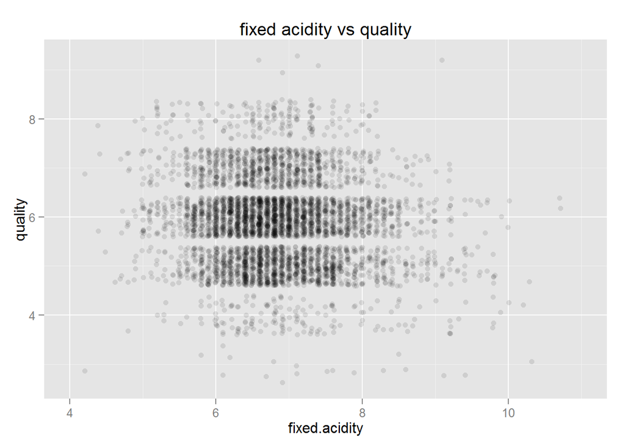

```
##
##  Pearson's product-moment correlation
##
## data:  whitwine$quality and whitwine$fixed.acidity
## t = -8.005, df = 4896, p-value = 1.48e-15
## alternative hypothesis: true correlation is not equal to 0
## 95 percent confidence interval:
##  -0.14121974 -0.08592991
## sample estimates:
##        cor
## -0.1136628
```

These two variables have a very small correlation of around -.11 if one rounds to the nearest hundredth. This is also hard to visually notice, and it isn’t very predictively useful, but it also might be interesting to research later.

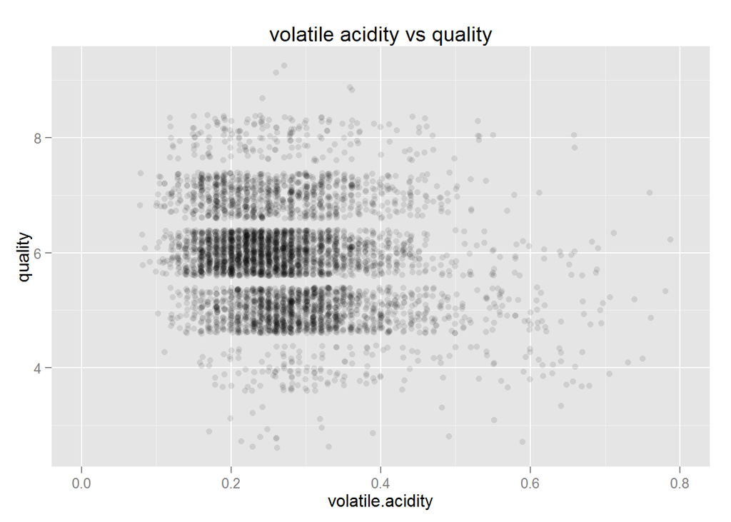

```
##
##  Pearson's product-moment correlation
##
## data:  whitwine$quality and whitwine$volatile.acidity
## t = -13.891, df = 4896, p-value < 2.2e-16
## alternative hypothesis: true correlation is not equal to 0
## 95 percent confidence interval:
##  -0.2215214 -0.1676307
## sample estimates:
##       cor
## -0.194723
```

Volatile acidity has a much stronger relationship than the last two variables. It isn’t as strong as what was found for density or alcohol, but it could be of value. It still is not likely easy to see.

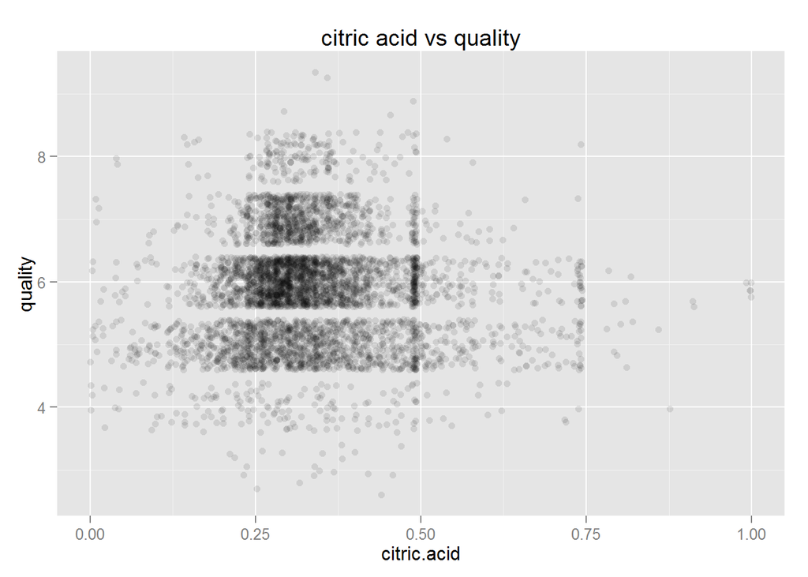

```
##
##  Pearson's product-moment correlation
##
## data:  whitwine$quality and whitwine$citric.acid
## t = -0.6444, df = 4896, p-value = 0.5193
## alternative hypothesis: true correlation is not equal to 0
## 95 percent confidence interval:
##  -0.03720595  0.01880221
## sample estimates:
##          cor
## -0.009209091
```

Citric acid has no linear relationship worth mentioning. We can’t even reject the null-hypothesis of zero correlation at the 95 percent confidence interval, and that’s even given an interval that is less than .05 + or -. Maybe there’s a complicated relationship that isn’t quite linear, but it’s also possible that citric acid has no effect for most wines.

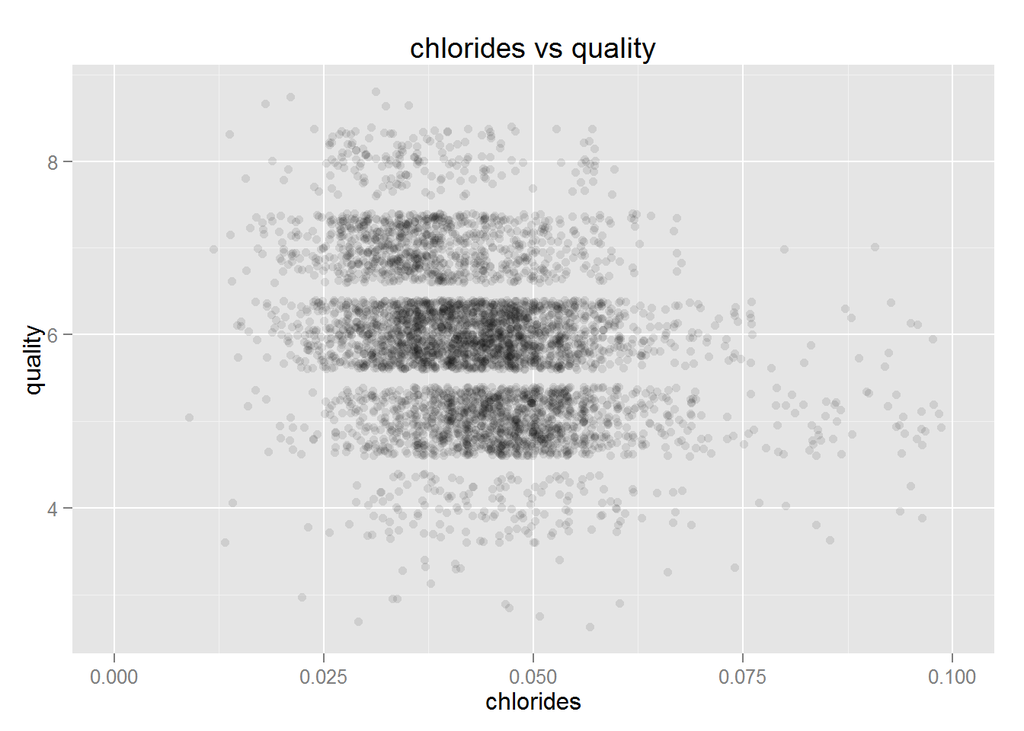

```
##
##  Pearson's product-moment correlation
##
## data:  whitwine$quality and whitwine$chloride
## t = -15.024, df = 4896, p-value < 2.2e-16
## alternative hypothesis: true correlation is not equal to 0
## 95 percent confidence interval:
##  -0.2365501 -0.1830039
## sample estimates:
##        cor
## -0.2099344
```

The correlation between chloride and quality is relatively high. It isn’t one of the highest, but at -.21 it’s potentially worth investigating. It’s still a relationship that is hard to tell from any graph as it’s significantly less than .5

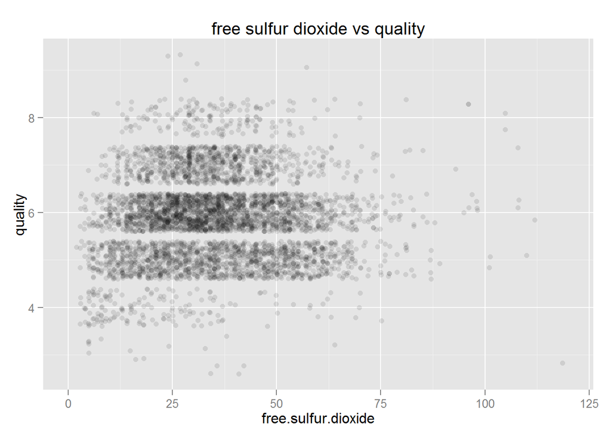

```
##
##  Pearson's product-moment correlation
##
## data:  whitwine$quality and whitwine$free.sulfur.dioxide
## t = 0.57085, df = 4896, p-value = 0.5681
## alternative hypothesis: true correlation is not equal to 0
## 95 percent confidence interval:
##  -0.01985292  0.03615626
## sample estimates:
##         cor
## 0.008158067
```

Free sulphur dioxide and quality is another example of two variables that may in practice have no relationship. The 95 percent confidence interval does not allow us to reject the idea that there is no relationship between the variables.

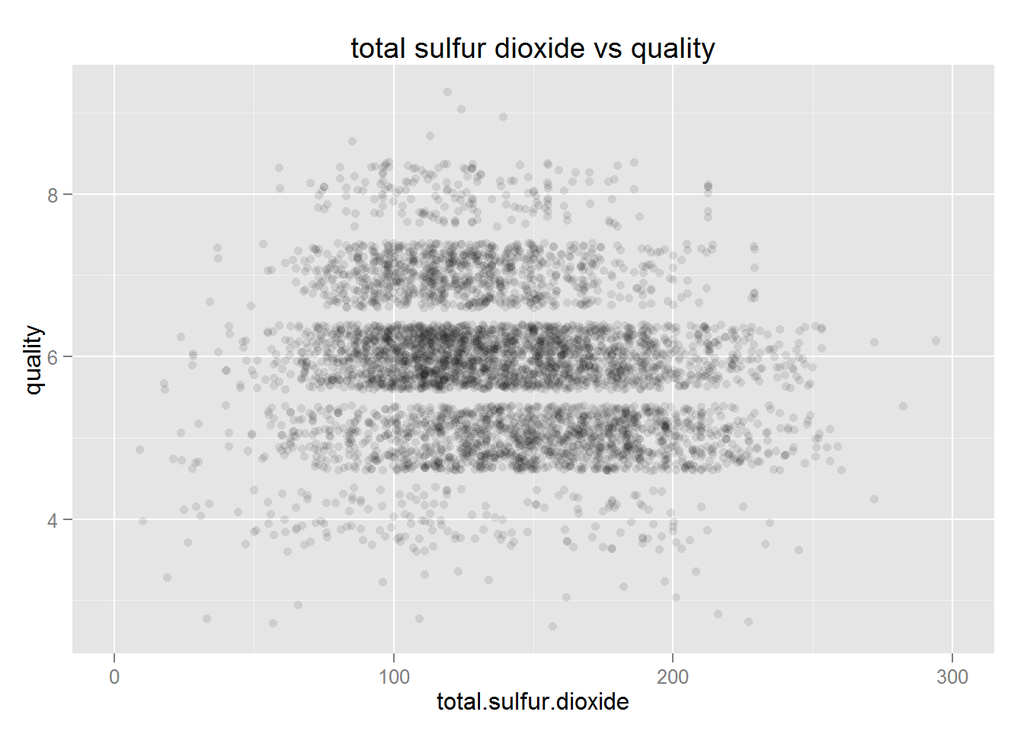

```
##
##  Pearson's product-moment correlation
##
## data:  whitwine$quality and whitwine$total.sulfur.dioxide
## t = -12.418, df = 4896, p-value < 2.2e-16
## alternative hypothesis: true correlation is not equal to 0
## 95 percent confidence interval:
##  -0.2017563 -0.1474524
## sample estimates:
##        cor
## -0.1747372
```

Interestingly, while free sulfur dioxide may have no relationship with quality, total sulfur dioxide does. Given that total sulfur dioxide is comprised of free sulfur dioxide and bound sulfur dioxide, this may suggest that the latter is the real variable for variances in wine quality.

This set of plots suggest to me a possible positive correlation between quality and alcohol content, as well as a negative correlation between quality and density.

### Investigating alcohol vs other variables

Because alcohol has the strongest correlation with quality, it may be of value to see how alcohol correlates with other variables.

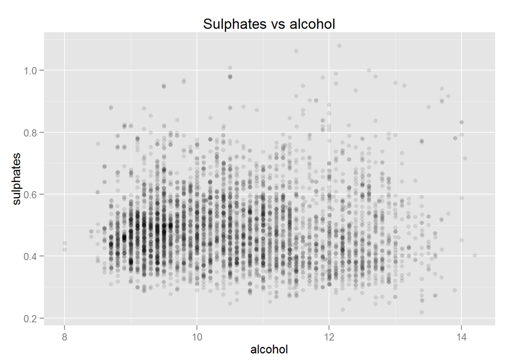

```
##
##  Pearson's product-moment correlation
##
## data:  whitwine$alcohol and whitwine$sulphates
## t = -1.22, df = 4896, p-value = 0.2225
## alternative hypothesis: true correlation is not equal to 0
## 95 percent confidence interval:
##  -0.04541705  0.01057885
## sample estimates:
##         cor
## -0.01743277
```

As can be noted, the correlation between alcohol and sulphates is not distinguishable from 0.

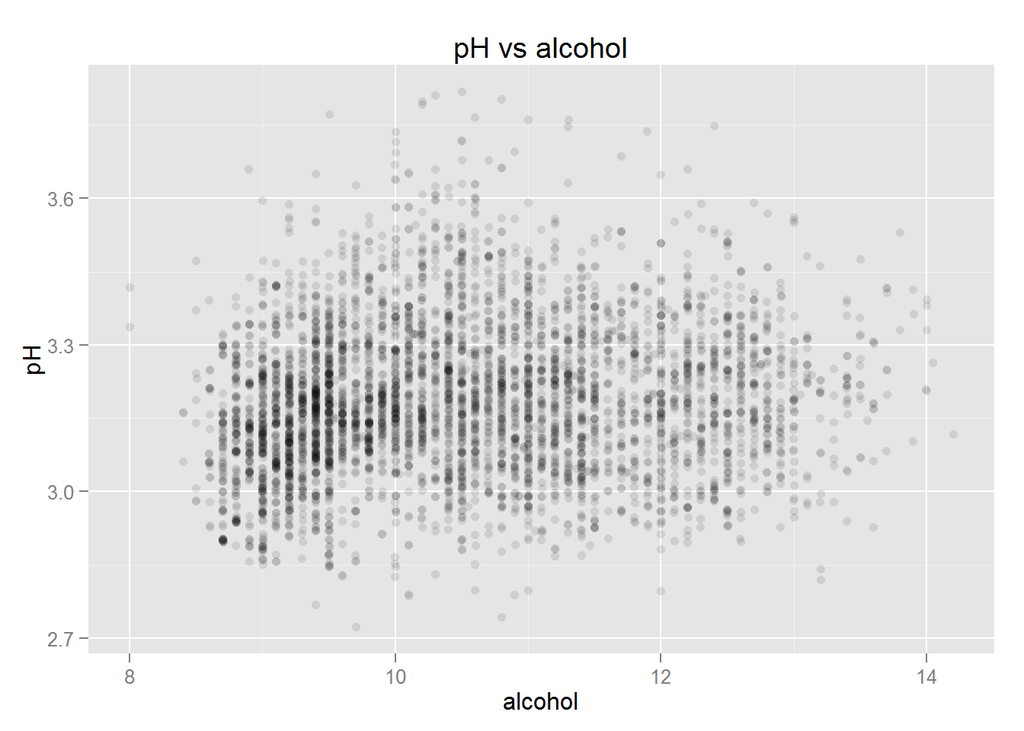

```
##
##  Pearson's product-moment correlation
##
## data:  whitwine$alcohol and whitwine$pH
## t = 8.5601, df = 4896, p-value < 2.2e-16
## alternative hypothesis: true correlation is not equal to 0
## 95 percent confidence interval:
##  0.09374446 0.14893205
## sample estimates:
##       cor
## 0.1214321
```

While it’s a low enough correlation where it’d be hard to tell visually, there is some correlation between pH and alcohol.

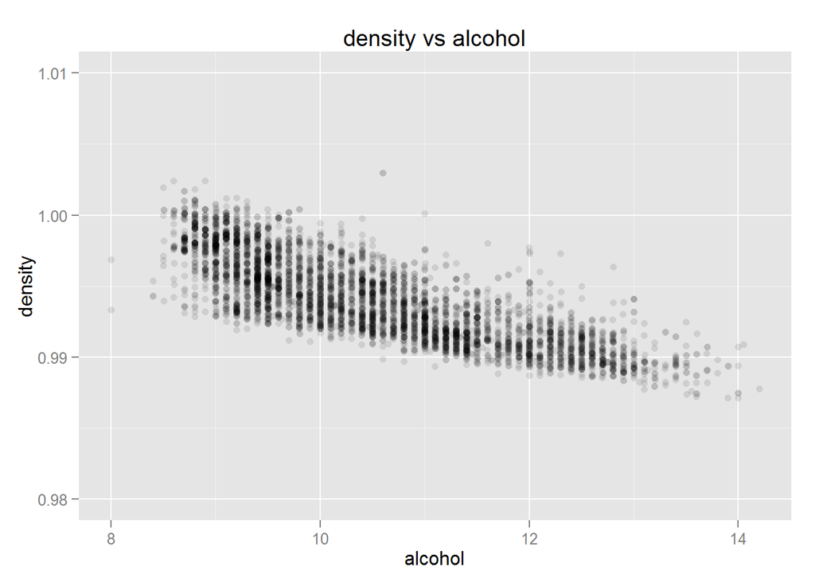

```
##
##  Pearson's product-moment correlation
##
## data:  whitwine$alcohol and whitwine$density
## t = -87.255, df = 4896, p-value < 2.2e-16
## alternative hypothesis: true correlation is not equal to 0
## 95 percent confidence interval:
##  -0.7908646 -0.7689315
## sample estimates:
##        cor
## -0.7801376
```

The correlation between density and alcohol is very strong and very obvious. It’s even clear upon looking at the visualization. It’s a negative relationship though, which makes the matter of explaining quality more difficult. Also, while this may be due to my lack of knowledge on wine, but I feel like it is a bit strange that there is so much of a relationship, while I recognize that alcohol isn’t dense, I would think there would be more of the variance explained by other variables.

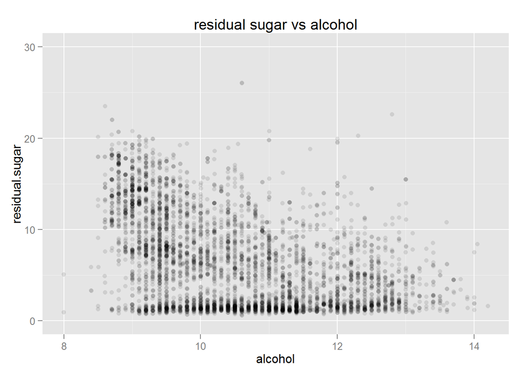

```
##
##  Pearson's product-moment correlation
##
## data:  whitwine$alcohol and whitwine$residual.sugar
## t = -35.321, df = 4896, p-value < 2.2e-16
## alternative hypothesis: true correlation is not equal to 0
## 95 percent confidence interval:
##  -0.4726723 -0.4280267
## sample estimates:
##        cor
## -0.4506312
```